# NRE_Final_Project

Chloe Swick

2023-12-01

# Stage 1–> Traditional Enforcement

## Stock Function

this function should describe how much fish stock there is (birth minus death/harvest)

from the objective function we want to describe how what the optimal TAC should be (MSY)

How far above MSY are we currently?

Shaefer Model:

$$X_{t+1} = X_{t} + rX_{t}
-\frac{rX_{t}^2}{K}$$

$$X_{t+1} = X_{t} + 0.2X_{t}
-\frac{0.2X_{t}^2}{2,265,128}$$

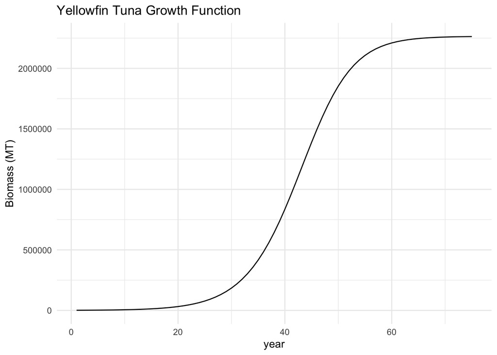

```r
 period = seq(1,75, by =1)
stock <- function(Y, int_stock, r, K, period) {
   stock <- vector(mode = "numeric", length = 75)

   stock[1] = int_stock

    for (i in 2:(75))
    {
    ### Stock dynamics
    stock[i] = stock[i-1] + (r * stock[i-1]) - (r*(stock[i-1])^2)/K  - Y
    }
   return(stock)
}

 stock1<-stock(Y=0, int_stock = 1000, r=.2, K=2265128)

 stock_data <- data.frame(period,stock1)

ggplot(data = stock_data,aes( x=period, y= stock1)) +
  geom_line() +
   labs(title = "Yellowfin Tuna Growth Function",
       x = "year",
       y = "Biomass (MT)") +
  theme_minimal()
```

```r
objective <- function(I, int_stock, discount, p, L, c, ce, r, K, period, effort, alpha) {

  #vectors
  stock <- vector(mode = "numeric", length = 21)
  benefits <- vector(mode = "numeric", length = 21)

  #initial values
  stock[1] = int_stock
  benefits[1] = p*(L+I[1]) - c*((L+I[1])^2/stock[1]) - ce*(effort) - alpha*effort*I[1]


  #for loop
  for (i in 2:(period+1))
    {
    ### Stock dynamics
    stock[i] = stock[i-1] + r * stock[i-1] * (1 - stock[i-1]/K) - (L + I[i-1])
    benefits[i] = p*(L + I[i]) - c*((L+I[i])^2/stock[i])
    - ce*(effort)  - alpha*effort*I[i]

  }

  t = seq(from = 0, period)
  pv = ((1/(1 + discount))^t) * benefits
  npv = sum(pv)

  return(-npv)

}
```

## Illegal fishing / enforcement

Model how much of total fishing is illegal fishing. this will be a function of what TAC is set at, and what enforcement/deterrence levels are

more enforcement will lead to less IUU, and get us closer to TAC

enforcement also costs money, the more money you spend on enforcement, the less you have for other things, or enforcement in other areas

## Optimization

how much enforcement is optimal? how do we get the highest NPV? (benefit is amount of legal fish landed, cost is cost of enforcement, want to minimize catch)

constraints–> 1. catch > or equal to TAC 2. enforcement costs < or equal to enforcement budget

```r
### Constraint: harvest < X
constraint <- function(I, int_stock, discount, p, L, c, ce, r, K, period, effort, alpha) {

 stock <- vector(mode = "numeric", length = 21)
  const <- vector(mode = "numeric", length = 21)

  ### Initial states
  stock[1] = int_stock
  const[1] = (L+I[1]) -stock[1]

  ### For-loop
  for (i in 2:(21)) {
    stock[i] = stock[i - 1] + r * stock[i - 1] * (1 - (stock[i - 1] / K)) - L - I[i - 1]
  } # End for-loop

    const[i] = (L+I[i]) - stock[i]

  return(const)
}
```

### with enforcement:

```r
## Use this options list for nloptr

local_opts<-list("algorithm"="NLOPT_LN_COBYLA",xtol_rel=1e-15)
options=list("algorithm"="NLOPT_LN_AUGLAG",xtol_rel=1e-15,maxeval=16000,"local_opts"=local_opts)

period = 20

output_enf = nloptr(x0=rep(1, times=21),
                 eval_f=objective,
                 eval_g_ineq = constraint,
                 lb=rep(0, times=21),
                 opts = options,
                 int_stock=883400, discount=.05, p=2397, L=113256, c=1000,
                 ce =4000, r=.2, K=2265128,
                 period =20, effort= .5, alpha = .4)

round(output_enf$solution, 3) #effort
```

```
##  [1] 19.751 19.068 18.372 17.701 17.061 16.449 15.866 15.308 14.774 14.264
## [11] 13.775 13.307 12.858 12.427 12.013 11.616 11.233 10.865 10.510 10.168
## [21]  9.940
```

```r
-output_enf$objective #PVNB
```

```
## [1] 3444048081
```

```r
#Making a table

stock_a <- function(I, int_stock=883400, discount=.05, p=2397, L=113256, c=1000, ce =0, r=.2, K=2265128,
                 period =20, effort= 0, alpha = 0) {

  #vectors
  stock <- vector(mode = "numeric", length = 21)
  benefits <- vector(mode = "numeric", length = 21)

  #initial values
  stock[1] = int_stock
  benefits[1] = p*(L+I[1]) - c*((L+I[1])/stock[1]) - ce*(effort) - alpha*effort*I[1]



  #for loop
  for (i in 2:(period+1))
    {
    ### Stock dynamics
    stock[i] = stock[i-1] + r * stock[i-1] * (1 - (stock[i-1]/K)) - L -I[i-1]
    benefits[i] = p*(L + I[i]) - c*((L+I[i])/stock[i])
    - ce*(effort[i])  - alpha*effort[i]*I[i]

  }

  t = seq(from = 0, period)
  pv = ((1/(1 + discount))^t) * benefits
  npv = sum(pv)


# This time we return a data frame with the variables we want in the table.  The value after the = indicates the column label.

  return(data.frame("Period"=t, "Present Value" =pv, "Stock"=stock, "Harvest" =I+L, "Illegal Fishing" = I))

}

# The next command is telling R to use the solution found above, choice, to evaluate the function stock and to round the values in the data frame to two places past the decimal point.  The second command says to make a table with these values.

tbl_enf=round(stock_a(output_enf$solution),3)      #  2 indicates rounding

kable(tbl_enf)
```

| Period | Present.Value | Stock | Harvest | Illegal.Fishing |
| --- | --- | --- | --- | --- |
| 0 | 271521846 | 883400.0 | 113275.8 | 19.751 |
| 1 | 258590675 | 877899.0 | 113275.1 | 19.068 |
| 2 | 246275318 | 872154.1 | 113274.4 | 18.372 |
| 3 | 234546533 | 866148.5 | 113273.7 | 17.701 |
| 4 | 223376387 | 859864.2 | 113273.1 | 17.061 |
| 5 | 212738268 | 853281.5 | 113272.4 | 16.449 |
| 6 | 202606829 | 846378.5 | 113271.9 | 15.866 |
| 7 | 192957933 | 839131.5 | 113271.3 | 15.308 |
| 8 | 183768594 | 831514.1 | 113270.8 | 14.774 |
| 9 | 175016919 | 823497.5 | 113270.3 | 14.264 |
| 10 | 166682060 | 815049.5 | 113269.8 | 13.775 |
| 11 | 158744162 | 806134.6 | 113269.3 | 13.307 |
| 12 | 151184316 | 796713.2 | 113268.9 | 12.858 |
| 13 | 143984514 | 786741.5 | 113268.4 | 12.427 |
| 14 | 137127607 | 776169.9 | 113268.0 | 12.013 |
| 15 | 130597261 | 764943.3 | 113267.6 | 11.616 |
| 16 | 124377923 | 752999.5 | 113267.2 | 11.233 |
| 17 | 118454779 | 740268.0 | 113266.9 | 10.865 |
| 18 | 112813720 | 726669.3 | 113266.5 | 10.510 |
| 19 | 107441313 | 712112.5 | 113266.2 | 10.168 |
| 20 | 102324853 | 696493.9 | 113265.9 | 9.940 |

### W/o enforcement

```r
## Use this options list for nloptr

local_opts<-list("algorithm"="NLOPT_LN_COBYLA",xtol_rel=1e-15)
options=list("algorithm"="NLOPT_LN_AUGLAG",xtol_rel=1e-15,maxeval=16000,"local_opts"=local_opts)

period = 20

output_no_enf = nloptr(x0=rep(1, times=21),
                 eval_f=objective,
                 #eval_g_ineq = constraint,
                 lb=rep(0, times=21),
                 opts = options,
                 int_stock=883400, discount=0, p=2397, L=0, c=0, ce =0, r=.2, K=2265128,
                 period =20, effort= 0, alpha = 0)

round(output_no_enf$solution, 3) #effort
```

```
##  [1] 14.516 14.516 14.516 14.516 14.516 14.516 14.516 14.516 14.516 14.516
## [11] 14.516 14.516 14.516 14.516 14.516 14.516 14.516 14.516 14.516 14.516
## [21] 14.516
```

```r
-output_no_enf$objective #PVNB
```

```
## [1] 730679.1
```

```r
#Making a table

stock_a <- function(I, int_stock=883400, discount=.05, p=2397, L=0, c=0, ce =0, r=.2, K=2265128,
                 period =20, effort= 0, alpha = 0) {

  #vectors
  stock <- vector(mode = "numeric", length = 21)
  benefits <- vector(mode = "numeric", length = 21)

  #initial values
  stock[1] = int_stock
  benefits[1] = p*(L+I[1]) - c*((L+I[1])/stock[1]) - ce*(effort) - alpha*effort*I[1]



  #for loop
  for (i in 2:(period+1))
    {
    ### Stock dynamics
    stock[i] = stock[i-1] + r * stock[i-1] * (1 - (stock[i-1]/K)) - L -I[i-1]
    benefits[i] = p*(L + I[i]) - c*((L+I[i])/stock[i])
    - ce*(effort[i])  - alpha*effort[i]*I[i]

  }

  t = seq(from = 0, period)
  pv = ((1/(1 + discount))^t) * benefits
  npv = sum(pv)


# This time we return a data frame with the variables we want in the table.  The value after the = indicates the column label.

  return(data.frame("Period"=t, "Present Value" =pv, "Stock"=stock, "Harvest" =I+L, "Illegal Fishing" = I))

}

# The next command is telling R to use the solution found above, choice, to evaluate the function stock and to round the values in the data frame to two places past the decimal point.  The second command says to make a table with these values.

tbl_no_enf=round(stock_a(output_no_enf$solution),3)      #  2 indicates rounding

kable(tbl_no_enf)
```

| Period | Present.Value | Stock | Harvest | Illegal.Fishing |
| --- | --- | --- | --- | --- |
| 0 | 34794.25 | 883400.0 | 14.516 | 14.516 |
| 1 | 33137.38 | 991160.3 | 14.516 | 14.516 |
| 2 | 31559.40 | 1102636.7 | 14.516 | 14.516 |
| 3 | 30056.58 | 1215799.5 | 14.516 | 14.516 |
| 4 | 28625.31 | 1328429.7 | 14.516 | 14.516 |
| 5 | 27262.20 | 1438284.2 | 14.516 | 14.516 |
| 6 | 25964.00 | 1543273.6 | 14.516 | 14.516 |
| 7 | 24727.62 | 1641621.7 | 14.516 | 14.516 |
| 8 | 23550.11 | 1731982.7 | 14.516 | 14.516 |
| 9 | 22428.68 | 1813499.9 | 14.516 | 14.516 |
| 10 | 21360.65 | 1885801.6 | 14.516 | 14.516 |
| 11 | 20343.47 | 1948947.7 | 14.516 | 14.516 |
| 12 | 19374.74 | 2003342.4 | 14.516 | 14.516 |
| 13 | 18452.13 | 2049634.0 | 14.516 | 14.516 |
| 14 | 17573.46 | 2088618.0 | 14.516 | 14.516 |
| 15 | 16736.63 | 2121154.6 | 14.516 | 14.516 |
| 16 | 15939.64 | 2148104.5 | 14.516 | 14.516 |
| 17 | 15180.61 | 2170285.6 | 14.516 | 14.516 |
| 18 | 14457.73 | 2188445.3 | 14.516 | 14.516 |
| 19 | 13769.26 | 2203248.1 | 14.516 | 14.516 |
| 20 | 13113.58 | 2215271.5 | 14.516 | 14.516 |

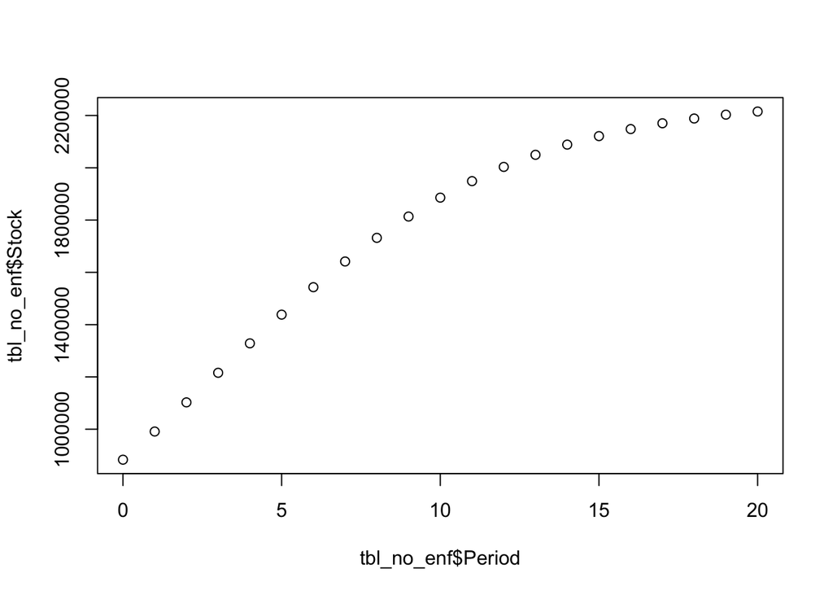

```r
plot(tbl_no_enf$Period, tbl_no_enf$Stock)
```

# Stage 2–> Enforcement with Skylight

## optimization

questions: 1. can TAC be reached with budget constraint? if not, how effective does Skylight need to be to reach TAC? if yes, how much money is saved in reaching TAC w/ Skylight how much faster can TAC be reached?

2. How do these results change when we have different effectiveness ratings for Skylight?

trying something new

```r
objective_new <- function(Y, int_stock, discount, p, c, r, K, period) {

  #vectors
  stock <- vector(mode = "numeric", length = 76)
  benefits <- vector(mode = "numeric", length = 76)

  #initial values
  stock[1] = int_stock
  benefits[1] = p*(Y[1]) - c*(Y[1]^2/stock[1])


  #for loop
  for (i in 2:(period+1))
    {
    ### Stock dynamics
     stock[i] = stock[i-1] + (r * stock[i-1]) - (r*(stock[i-1])^2)/K  - Y[i-1]
    benefits[i] = p*(Y[i]) - c*(Y[i]^2/stock[i])

  }

  t = seq(from = 0, period)
  pv = ((1/(1 + discount))^t) * benefits
  npv = sum(pv)

  return(-npv)

}
```

```r
### Constraint: harvest < X
constraint_new <- function(Y, int_stock, discount, p, c,  r, K, period) {

 stock <- vector(mode = "numeric", length = 76)
  const <- vector(mode = "numeric", length = 76)

  ### Initial states
  stock[1] = int_stock
  const[1] = Y[1] -stock[1]

  ### For-loop
  for (i in 2:(period+1)) {
     stock[i] = stock[i-1] + (r * stock[i-1]) - (r*(stock[i-1])^2)/K  - Y[i-1]
    const[i] = Y[i] - stock[i-1]
  } # End for-loop

  return(const)
}
```

```r
## Use this options list for nloptr

local_opts<-list("algorithm"="NLOPT_LN_COBYLA",xtol_rel=1e-15)
options=list("algorithm"="NLOPT_LN_AUGLAG",xtol_rel=1e-15,maxeval=16000,"local_opts"=local_opts)

period = 75

output_new = nloptr(x0=rep(1, times=76),
                 eval_f=objective_new,
                 eval_g_ineq = constraint_new,
                 lb=rep(0, times=76),
                 opts = options,
                 int_stock=8000, discount=.05, p=10, c=7, r=.2, K=2265128,
                 period =75)

round(output_new$solution, 3) #effort
```

```
##  [1] 7.001 6.761 6.523 6.295 6.079 5.873 5.677 5.490 5.312 5.142 4.981 4.827
## [13] 4.680 4.541 4.408 4.281 4.161 4.046 3.937 3.833 3.733 3.639 3.549 3.463
## [25] 3.382 3.304 3.230 3.160 3.092 3.029 2.968 2.910 2.854 2.802 2.752 2.704
## [37] 2.659 2.615 2.574 2.535 2.498 2.462 2.428 2.396 2.365 2.336 2.308 2.281
## [49] 2.256 2.232 2.209 2.187 2.166 2.146 2.128 2.110 2.092 2.076 2.061 2.046
## [61] 2.032 2.018 2.006 1.993 1.982 1.971 1.960 1.950 1.941 1.932 1.923 1.915
## [73] 1.907 1.899 1.892 1.904
```

```r
-output_new$objective #PVNB
```

```
## [1] 923.8892
```

```r
#Making a table

stock_a <- function(Y, int_stock=8000, discount=.05, p=10, c=7, r=.2, K=2265128, period =75) {

 stock <- vector(mode = "numeric", length = 76)
  benefits <- vector(mode = "numeric", length = 76)

  #initial values
  stock[1] = int_stock
  benefits[1] = p*(Y[1]) - c*(Y[1]^2/stock[1])


  #for loop
  for (i in 2:(period+1))
    {
    ### Stock dynamics
    stock[i] = stock[i-1] + (r * stock[i-1]) - (r*(stock[i-1])^2)/K  - Y[i-1]
    benefits[i] = p*(Y[i]) - c*(Y[i]^2/stock[i])

  }

  t = seq(from = 0, period)
  pv = ((1/(1 + discount))^t) * benefits
  npv = sum(pv)


# This time we return a data frame with the variables we want in the table.  The value after the = indicates the column label.

  return(data.frame("Period"=t, "Present Value" =pv, "Stock"=stock, "Harvest" =Y))

}

# The next command is telling R to use the solution found above, choice, to evaluate the function stock and to round the values in the data frame to two places past the decimal point.  The second command says to make a table with these values.

tbl_new=round(stock_a(output_new$solution),3)      #  2 indicates rounding

kable(tbl_new)
```

| Period | Present.Value | Stock | Harvest |
| --- | --- | --- | --- |
| 0 | 69.972 | 8000.000 | 7.001 |
| 1 | 64.359 | 9587.348 | 6.761 |
| 2 | 59.138 | 11489.940 | 6.523 |
| 3 | 54.365 | 13769.749 | 6.295 |
| 4 | 50.000 | 16500.662 | 6.079 |
| 5 | 46.007 | 19770.675 | 5.873 |
| 6 | 42.354 | 23684.424 | 5.677 |
| 7 | 39.010 | 28366.103 | 5.490 |
| 8 | 35.948 | 33962.789 | 5.312 |
| 9 | 33.144 | 40648.188 | 5.142 |
| 10 | 30.575 | 48626.796 | 4.981 |
| 11 | 28.220 | 58138.395 | 4.827 |
| 12 | 26.061 | 69462.802 | 4.680 |
| 13 | 24.080 | 82924.651 | 4.541 |
| 14 | 22.262 | 98897.878 | 4.408 |
| 15 | 20.594 | 117809.449 | 4.281 |
| 16 | 19.061 | 140141.602 | 4.161 |
| 17 | 17.652 | 166431.672 | 4.046 |
| 18 | 16.358 | 197268.227 | 3.937 |
| 19 | 15.167 | 233281.948 | 3.833 |
| 20 | 14.071 | 275129.438 | 3.733 |
| 21 | 13.062 | 323467.978 | 3.639 |
| 22 | 12.132 | 378919.469 | 3.549 |
| 23 | 11.276 | 442022.388 | 3.463 |
| 24 | 10.486 | 513171.945 | 3.382 |
| 25 | 9.757 | 592550.805 | 3.304 |
| 26 | 9.084 | 680055.753 | 3.230 |
| 27 | 8.463 | 775229.264 | 3.160 |
| 28 | 7.889 | 877208.253 | 3.092 |
| 29 | 7.358 | 984704.132 | 3.029 |
| 30 | 6.866 | 1096027.146 | 2.968 |
| 31 | 6.412 | 1209162.709 | 2.910 |
| 32 | 5.991 | 1321898.139 | 2.854 |
| 33 | 5.600 | 1431986.529 | 2.802 |
| 34 | 5.238 | 1537324.120 | 2.752 |
| 35 | 4.902 | 1636112.294 | 2.704 |
| 36 | 4.590 | 1726977.773 | 2.659 |
| 37 | 4.301 | 1809034.360 | 2.615 |
| 38 | 4.031 | 1881883.175 | 2.574 |
| 39 | 3.781 | 1945561.063 | 2.535 |
| 40 | 3.548 | 2000454.939 | 2.498 |
| 41 | 3.331 | 2047201.811 | 2.462 |
| 42 | 3.128 | 2086591.285 | 2.428 |
| 43 | 2.940 | 2119481.758 | 2.396 |
| 44 | 2.764 | 2146735.619 | 2.365 |
| 45 | 2.600 | 2169174.118 | 2.336 |
| 46 | 2.446 | 2187549.611 | 2.308 |
| 47 | 2.303 | 2202531.585 | 2.281 |
| 48 | 2.169 | 2214702.618 | 2.256 |
| 49 | 2.044 | 2224560.929 | 2.232 |
| 50 | 1.926 | 2232526.805 | 2.209 |
| 51 | 1.816 | 2238950.991 | 2.187 |
| 52 | 1.713 | 2244123.703 | 2.166 |
| 53 | 1.617 | 2248283.442 | 2.146 |
| 54 | 1.526 | 2251625.154 | 2.128 |
| 55 | 1.441 | 2254307.497 | 2.110 |
| 56 | 1.362 | 2256459.150 | 2.092 |
| 57 | 1.287 | 2258184.193 | 2.076 |
| 58 | 1.216 | 2259566.621 | 2.061 |
| 59 | 1.150 | 2260674.105 | 2.046 |
| 60 | 1.088 | 2261561.087 | 2.032 |
| 61 | 1.029 | 2262271.314 | 2.018 |
| 62 | 0.974 | 2262839.912 | 2.006 |
| 63 | 0.922 | 2263295.062 | 1.993 |
| 64 | 0.873 | 2263659.360 | 1.982 |
| 65 | 0.827 | 2263950.916 | 1.971 |
| 66 | 0.783 | 2264184.239 | 1.960 |
| 67 | 0.742 | 2264370.953 | 1.950 |
| 68 | 0.703 | 2264520.361 | 1.941 |
| 69 | 0.667 | 2264639.916 | 1.932 |
| 70 | 0.632 | 2264735.580 | 1.923 |
| 71 | 0.599 | 2264812.127 | 1.915 |
| 72 | 0.568 | 2264873.378 | 1.907 |
| 73 | 0.539 | 2264922.390 | 1.899 |
| 74 | 0.512 | 2264961.609 | 1.892 |
| 75 | 0.490 | 2264992.992 | 1.904 |